# `GainCurvePlotC`

#### Description

Plot the cumulative gain curve of a sort-order with costs.

#### Usage

```
GainCurvePlotC(frame, xvar, costVar, truthVar, title, ...,
estimate_sig = FALSE, large_count = 1000)
```

#### Arguments

- `frame`: data frame to get values from
- `xvar`: name of the independent (input or model score) column in frame
- `costVar`: cost of each item (drives x-axis sum)
- `truthVar`: name of the dependent (output or result to be modeled) column in frame
- `title`: title to place on plot
- `...` : no unnamed argument, added to force named binding of later arguments
- `estimate_sig`: (logical), if TRUE compute significance
- `large_count`: numeric, upper bound target for number of plotting points

#### Examples

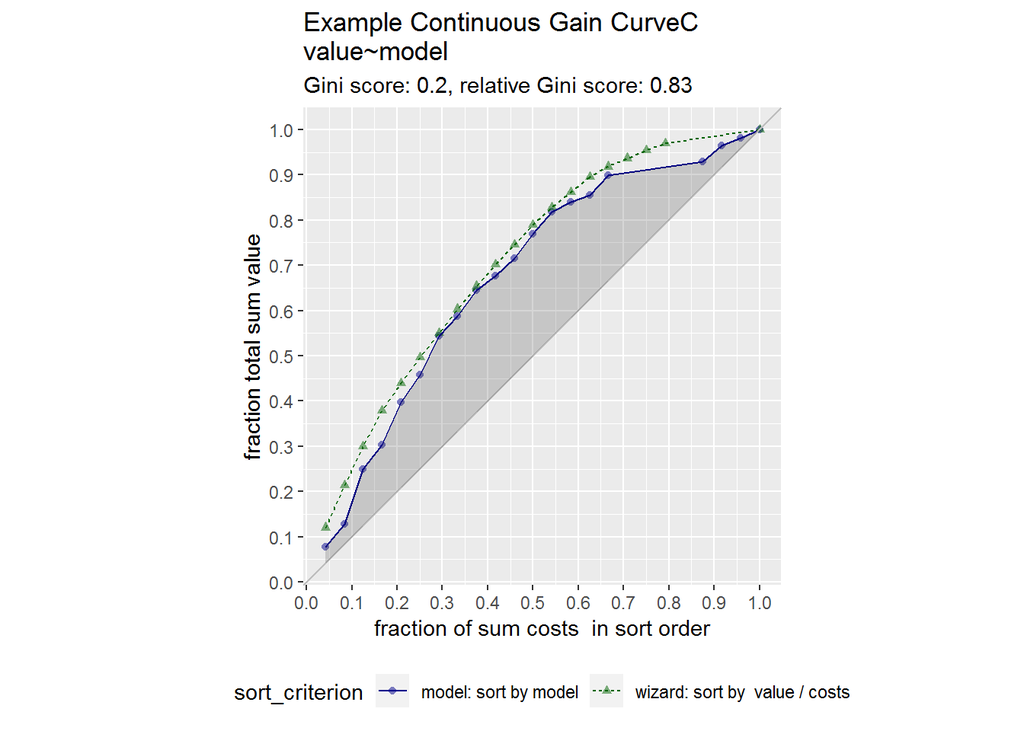

```r
set.seed(3490)
y = abs(rnorm(20)) + 0.1
x = abs(y + 0.5*rnorm(20))
frm = data.frame(model=x, value=y)
frm$costs=1
frm$costs[1]=5
WVPlots::GainCurvePlotC(frm, "model", "costs", "value",title="Example Continuous Gain CurveC")
```

#### Details

- GainCurvePlotC plots a cumulative gain curve for the case where items have an additional cost, in addition to an outcome value.
- The x-axis represents the fraction of total cost experienced when items are sorted by score, and the y-axis represents the cumulative summed true outcome represented by the items seen so far.
- For comparison, GainCurvePlotC also plots the “wizard curve”: the gain curve when the data is sorted according to its true outcome/cost (the optimal sort order).
- To improve presentation quality, the plot is limited to approximately large_count points (default: 1000). For larger data sets, the data is appropriately randomly sampled down before plotting.

#### See Also

GainCurvePlot